# Revisión de comandos

Categoría rarefacción-extrapolación por cobertura

David Mateo Murillo Proyecto: paquetes de R para estimar y comparar la riqueza: revisión para una correcta elección

Ago-2024

# Comandos relacionados con la temática

Después de haber hecho la revisión de los 15 paquetes, a continuación se listan los comandos relacionados con la rarefacción-extrapolación por cobertura, y el paquete al que pertenecen.

```
# A tibble: 6 × 4
  comando                categoria otros paquetes
  <chr>                  <chr>     <chr> <chr>
1 estimateD              C1        B     iNEXT
2 iNEXT                  B         C1D1  iNEXT
3 rarefaction.sample     C1        B     rareNMtests
4 rarefaction.individual B         C1    rareNMtests
5 Coverage               C2        C1    entropart
6 Coverage2Size          C1        <NA>  entropart
```

NOTA: Más adelante se menciona el comando `iNEXT()` junto con `ggiNEXT()`, sin embargo, éste último no fue colocado en la lista porque corresponde más a un método de apoyo, y no un comando que de forma independiente haga rarefacción-extrapolación por cobertura.

## Carga de las librerías respectivas

```r
# Librerias y funciones
library(iNEXT)
library(rareNMtests)
library(entropart)


source('https://raw.githubusercontent.com/paguzmang/funciones/master/describe_diver.R')
```

## Cargue de los datos

Estos registros fueron publicados a través del SiB Colombia como un DwC-A, bajo una licencia [CC-BY-NC](https://creativecommons.org/licenses/by-nc/4.0/legalcode).

> Ramírez Martínez N M, Rodríguez Ortíz J, Urrego Salinas M D P, Gonzalez Aguas C C, García concha J H (2023): Artrópodos de los Parques Distritales Ecológicos de Montaña. v1.4. Secretaría Distrital de Ambiente. Dataset/Occurrence. https://doi.org/10.15472/cwrg3e

El DwC fue filtrado y organizado de forma que la primera columna indica el evento de muestreo (en el Parque Distrital respectivo), y el resto de columnas corresponden a las familias de artrópodos observadas en el estudio, por lo que cada evento de muestreo está en una fila. Esto obedece a que consideramos que uno de los formatos más empleados al momento de tomar registros en campo es el de *sitios en fila y especies en columna*. El archivo `datos_sitio_fila.rds` se puede descargar [aquí](https://github.com/Sleiven/Paquetes-Riqueza/raw/Prueba_datos/datos_sitio_fila.rds).

El script con el cual se creó la tabla a partir del archivo .txt del DwC está [disponible](https://github.com/Sleiven/Paquetes-Riqueza/blob/main/Occurrence_DwC_to_sitiosFila.R), por lo que puede utilizarse para cualquier otro tipo de evento de muestreo publicado a través del SiB Colombia, lo que le dará más visibilidad a la información que es publicada y acompañada por el EC-SiB.

```
#> Se importan los datos
```

```r
ensamblaje <- readRDS("datos_sitio_fila.rds")
```

```r
# Se muestra cantidad de filas y columnas (Sitio de muestreo + 136 familias)
# También se muestra parte de la tabla
dim(ensamblaje); ensamblaje[1:6, 1:6]
```

```
[1] 1276  137
```

```
# A tibble: 6 × 6
  eventID     Melyridae Araneidae Erebidae Cosmetidae Blattidae
  <chr>           <int>     <int>    <int>      <int>     <int>
1 ENGA_12_RED         1         0        0          0         0
2 ENGA_12_RED         0         1        0          0         0
3 ENGA_12_RED         0         1        0          0         0
4 SOR_7_MM            0         0        1          0         0
5 SOR_2_TP            0         0        0          1         0
6 SOR_2_TP            0         0        0          0         4
```

```r
# Se quita primera columna para obtener valores basicos de todo el ensamblaje
(describe_ensa <- ensamblaje %>%
                    select(-eventID) %>%
                      colSums() %>%
                        describe_diver())
```

```
     N Riq f1 f2        H      q1        H1
1 4944 136 15 19 3.888783 48.8514 0.7915848
```

Entonces este ensamblaje obtuvo 4944 individuos, con una riqueza de 136 familias, donde 15 de ellas se observaron una vez; 19 se observaron dos veces.

## `estimateD` {iNEXT}

Para utilizar este comando, se permiten tres formatos de ingreso:

Una *lista* en la cual cada elemento es un vector de **abundancia** (o frecuencias de **incidencia**) de las especies. Por ejemplo:

```r
data(spider) # Datos asociados al paquete
spider
```

```
$Girdled
 [1] 46 22 17 15 15  9  8  6  6  4  2  2  2  2  1  1  1  1  1  1  1  1  1  1  1
[26]  1

$Logged
 [1] 88 22 16 15 13 10  8  8  7  7  7  5  4  4  4  3  3  3  3  2  2  2  2  1  1
[26]  1  1  1  1  1  1  1  1  1  1  1  1
```

O una *matriz* o *dataframe* organizada con *especies en filas* y sitios en columna (para abundancia) o de especies x unidades de muestreo (para incidencia). Con respecto a los datos ejemplo, ajustarlo a este formato es el más directo porque requiere **dos pasos** (sin contar la modificación de los nombres):

```r
# Juntar todas las filas que pertenecen al mismo sitio (cuatro Parques Distritales)
ensamblaje_unif <- ensamblaje %>%

  #> Crear nueva columna con las dos primeras letras de cada sitio para unificarlos
  mutate(sitio = substr(eventID, start = 1, stop = 2)) %>%

  #> Eliminar la columna con el nombre amplio de sitio
  select(sitio, everything(), -eventID)

# 1. Sumar las abundancias de un mismo Parque Distrital
ensamblajes <- ensamblaje_unif %>%
  group_by(sitio) %>%
  summarise(across(everything(), sum))
```

```
#> Muestra de la tabla
```

```r
print('tabla intermedia')
ensamblajes[, 1:6]

# 2. Ajustar tabla a familias x sitio
artropodos <- ensamblajes %>%
  column_to_rownames("sitio") %>%
  t()
```

```
#> Muestra de la tabla final
```

```r
print('tabla final')
head(artropodos)
```

```
[1] "tabla intermedia"
# A tibble: 4 × 6
  sitio Melyridae Araneidae Erebidae Cosmetidae Blattidae
  <chr>     <int>     <int>    <int>      <int>     <int>
1 EN           13        51        1         58        19
2 NE            0        13        0          0         2
3 SO           28         2        1         34         7
4 ZU            3        23        1         88         0
[1] "tabla final"
                EN NE SO ZU
Melyridae       13  0 28  3
Araneidae       51 13  2 23
Erebidae         1  0  1  1
Cosmetidae      58  0 34 88
Blattidae       19  2  7  0
Sclerosomatidae  5  0  6  3
```

Para realizar rarefacción o extrapolación por cobertura con este comando, es necesario modificar **tres argumentos** (además de los datos):

- `datatype`, para especificar el tipo de datos. El valor por defecto es `'abundance'`, pero también admite `'incidence_raw'` en caso de ser una matriz de incidencia de muestras, o `'incidence_freq'` para *frecuencias* de incidencias en muestreos basados en unidades, en cuyo caso la primer entrada debe ser el número total de unidades de muestreo.
- `q`, para especificar el orden de diversidad. Admite un número o u vector, pero en este contexto siempre se utilizaría el valor de `0`.
- `base`, para establecer si se utilizará el tamaño muestral o la cobertura. En este caso, siempre se debe modificar a `'coverage'`.

A continuación se muestra el ejemplo con la matriz `artropodos`

```r
estimateD(artropodos, q = 0, base = 'coverage') # No se especifica datataype = 'abundance' porque es el valor por defecto
```

```
  Assemblage         m        Method Order.q       SC       qD   qD.LCL
1         EN 1230.7176   Rarefaction       0 0.986109 91.50879 86.28201
2         NE  838.4507   Rarefaction       0 0.986109 59.42566 49.07118
3         SO 1206.0000 Extrapolation       0 0.986109 70.18282 39.27951
4         ZU 1238.4638 Extrapolation       0 0.986109 91.11021 81.61597
     qD.UCL
1  96.73556
2  69.78013
3 101.08614
4 100.60444
```

El resultado que entrega es una impresión de cada uno de los ensamblajes **a un mismo valor de cobertura (SC)**, donde se informa, **para cada sitio**, **cuántos individuos representa (m)**, y si esto es por debajo del valor de cobertura de la muestra original (`Method = Rarefaction`), o por encima del valor original (`Method = Extrapolation`). Además de mostrar el **valor de riqueza promedio para esa cobertura** (qD) y los valores de un **intervalo de confianza** del 95%.

### Referencia

Como referencia, se muestran los valores de cantidad de individuos (N) y riqueza observada (Riq) en cada uno de los sitios.

```r
(ref <- apply(X = artropodos, MARGIN = 2, FUN = describe_diver))
```

```
$EN
     N Riq f1 f2        H       q1      H1
1 2378 102 15  8 3.786373 44.09616 0.81868

$NE
    N Riq f1 f2        H       q1        H1
1 969  61 10 12 2.800044 16.44537 0.6811311

$SO
    N Riq f1 f2        H       q1        H1
1 603  58 17  6 3.059246 21.31148 0.7534266

$ZU
    N Riq f1 f2        H       q1        H1
1 994  87 20 15 3.605278 36.79191 0.8072889
```

Viendo estos valores, corroboramos que 1231 individuos (aproximadamente) es una rarefacción para el sitio EN, pues allí se registraron 2378; mientras que para SO, 1206 individuos es una extrapolación, puesto que allí se registraron 603. Entonces se podría decir que, si se quiere llegar al mismo sitio de cobertura de los cuatro sitios, se debe aumentar el esfuerzo en SO y ZU.

Ahora, el comando `estimateD` **también permite manipular** los siguientes aspectos:

Por ejemplo, se hará una rarefacción-extrapolación para los valores de cobertura del 85% y 99%, con un intervalo de confianza del 98%, con 100 réplicas bootstrap:

```
#> Establecer semilla para reproducibilidad de las aleatorizaciones
```

```r
set.seed(23)
estimateD(artropodos, q = 0, base = 'coverage',
          level = c(0.85,0.99), conf = 0.98, nboot = 100)
```

```
Warning in FUN(X[[i]], ...): The maximum size of the extrapolation exceeds
double reference sample size, the results for q = 0 may be subject to large
prediction bias.
```

```
  Assemblage          m        Method Order.q   SC       qD   qD.LCL    qD.UCL
1         EN  136.19673   Rarefaction       0 0.85 47.84191 45.06969  50.61414
2         EN 1609.55278   Rarefaction       0 0.99 95.96516 86.91941 105.01091
3         NE   94.45587   Rarefaction       0 0.85 27.90027 24.69470  31.10584
4         NE  980.71697 Extrapolation       0 0.99 61.11903 52.95445  69.28361
5         SO   93.88893   Rarefaction       0 0.85 28.79299 24.61239  32.97359
6         SO 1486.45117 Extrapolation       0 0.99 73.50506 50.45282  96.55730
7         ZU  126.55451   Rarefaction       0 0.85 41.69801 37.54031  45.85572
8         ZU 1456.19689 Extrapolation       0 0.99 93.68992 76.25745 111.12239
```

NOTA: La razón por la que se usa `set.seed()` es porque el comando tiene un componente de aleatorización, por lo que al usar el comando se garantiza reproducibilidad.

En este caso, se muestra el warning “El tamaño máximo de extrapolación excede el doble de la muestra, el resultado […] puede estar sujeto a un gran sesgo de predicción”, porque para SO se superó el doble de individuos registrados (603 * 2 = 1206).

Si bien al haber utilizado dos niveles (85 y 99)% los resultados se ven un poco apeñuzcados, este comando me parece muy bueno para obtener esas extrapolaciones o rarefacciones de la cobertura, más porque ya hace el cálculo considerando las recomendaciones de la literatura.

## `iNEXT` + `ggiNEXT` {iNEXT}

Este comando admite exactamente los mismos formatos que el anterior (por lo que sirve tanto para **abundancia** como para **incidencia**, y **solo requeriría dos pasos** desde los datos ejemplo), y trabaja por defecto con la riqueza (`q = 0`), por lo que necesitaríamos **modificar solo** el argumento de `datatype` (para indicar si es abundancia o incidencia).

A continuación se modifican los datos ejemplo a uno de los formatos aceptados por el comando:

```r
# Juntar todas las filas que pertenecen al mismo sitio (cuatro Parques Distritales)
ensamblaje_unif <- ensamblaje %>%

  #> Crear nueva columna con las dos primeras letras de cada sitio para unificarlos
  mutate(sitio = substr(eventID, start = 1, stop = 2)) %>%

  #> Eliminar la columna con el nombre amplio de sitio
  select(sitio, everything(), -eventID)

# 1. Sumar las abundancias de un mismo Parque Distrital
ensamblajes <- ensamblaje_unif %>%
  group_by(sitio) %>%
  summarise(across(everything(), sum))

# 2. Ajustar tabla a familias x sitio
artropodos <- ensamblajes %>%
  column_to_rownames("sitio") %>%
  t()
```

Se ingresan los datos en el comando:

```r
set.seed(24)
res <- iNEXT(artropodos) # También se omitió datatype porque por defecto es 'abundance'
```

Sin embargo, si se imprimiera el resultado de `iNEXT()` nos encontraríamos con una impresión de cuatro resultados, que contiene:

1. Una tabla que muestra la cantidad de individuos, las especies observadas, el valor de cobertura, y las frecuencias de cada uno de los sitios.
2. Tabla de estimaciones de riqueza y cobertura para cada uno de los sitios a diferentes tamaños de muestra.
3. Tabla de estimaciones de riqueza para cada uno de los sitios a diferentes niveles de cobertura.
4. Otros estimadores de diversidad para cada uno de los sitios.

En el contexto de la rarefacción-extrapolación por cobertura, solo nos interesaría la tercer sección, pues las otras corresponden a otros tipos de resultados (aclaro que el primero tampoco corresponde porque solo muestra el valor observado de cobertura, no una rarefacción o extrapolación). Esta sección se puede obtener individualmente de la siguiente forma:

```r
# Se imprimen las primeras y últimas filas de la tabla de interés
# Así como la cantidad de filas y columna de la tabla
print("head")
head(res$iNextEst$coverage_based)
print("-----------------------------------------------------------------------")
print("tail")
tail(res$iNextEst$coverage_based)
print("-----------------------------------------------------------------------")
print("dimensions")
dim(res$iNextEst$coverage_based)
```

```
[1] "head"
  Assemblage         SC   m      Method Order.q        qD     qD.LCL    qD.UCL
1         EN 0.04051917   1 Rarefaction       0  1.000004  0.9364309  1.063577
2         EN 0.84664805 133 Rarefaction       0 47.355481 44.9231327 49.787830
3         EN 0.92126036 265 Rarefaction       0 61.681608 58.4739763 64.889239
4         EN 0.94847215 397 Rarefaction       0 70.067188 66.5233067 73.611070
5         EN 0.96253768 529 Rarefaction       0 75.860625 72.0665075 79.654742
6         EN 0.97098462 661 Rarefaction       0 80.210162 76.1867005 84.233623
[1] "-----------------------------------------------------------------------"
[1] "tail"
    Assemblage        SC    m        Method Order.q       qD   qD.LCL   qD.UCL
155         ZU 0.9933452 1726 Extrapolation       0 95.90780 69.41327 122.4023
156         ZU 0.9938476 1778 Extrapolation       0 96.24087 69.28161 123.2001
157         ZU 0.9943206 1831 Extrapolation       0 96.55448 69.15611 123.9528
158         ZU 0.9947493 1883 Extrapolation       0 96.83873 69.04116 124.6363
159         ZU 0.9951457 1935 Extrapolation       0 97.10152 68.93389 125.2692
160         ZU 0.9955189 1988 Extrapolation       0 97.34897 68.83206 125.8659
[1] "-----------------------------------------------------------------------"
[1] "dimensions"
[1] 160   8
```

Así que el resultado de por sí, **aunque completo, puede ser dificil de visualizar**. Ahí es donde entra **la ayuda de `ggiNEXT`**, pues con pasarle el resultado de `iNEXT`, y específicar **el argumento `type = 3`**, se obtiene una gráfica bastante estilizada de la rarefacción-extrapolación por cobertura:

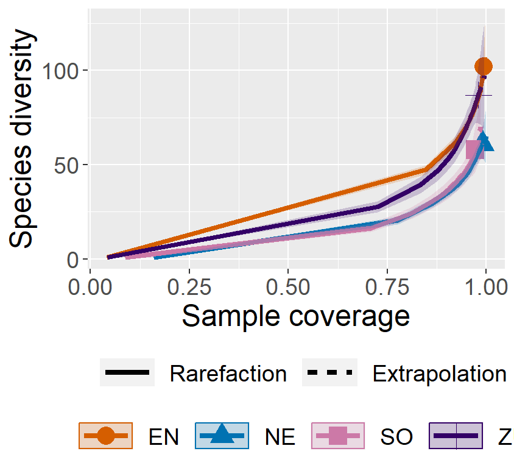

```r
library(ggplot2)
ggiNEXT(res, type = 3)
```

*NOTA*: Aunque en el eje y diga “Species diversity”, como por defecto se utiliza `q = 0`, se tiene certeza que los valores se refieren a la riqueza.

Además, en caso de que no se tenga instalado el paquete `ggplot2`, **también se puede utilizar `plot()`** dando un resultado bastante bueno:

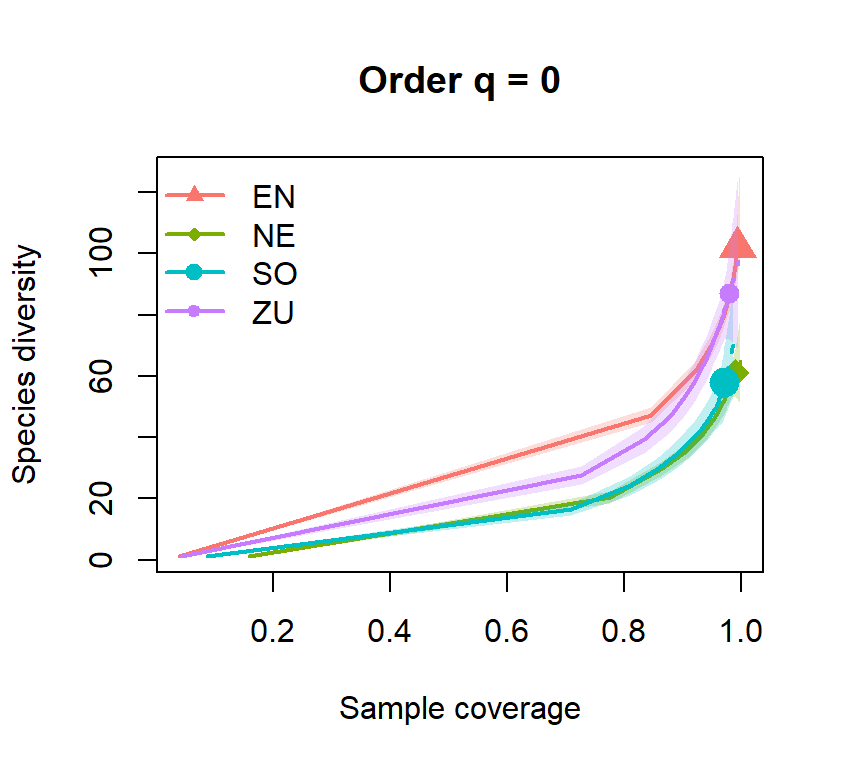

```r
plot(res, type = 3)
```

Volviendo a los argumentos de este conjunto de comandos, `iNEXT` **tiene las siguientes opciones útiles** para la rarefacción-extrapolación por cobertura:

- `endpoint`, para definir el **valor hasta el cual se quiere llevar la cobertura**. Por defecto, toma el valor del doble del tamaño de la muestra.
- `knots`, para controlar la **cantidad de pasos (o valores) que se quieren** dentro de cada ensamblaje. Este tiene por defecto un valor de 40 (es decir, para cada sitio, se calculan 40 valores desde el punto 0 hasta el `endpoint`). Esto también sirve porque se sabría que los valores del sitio 1 están entre las lineas 1-40; el 2 de las 41-80 y así sucesivamente.
- `se` valor `TRUE` o `FALSE` que establece **si se calcula el intervalo de confianza** (por defecto se calcula)
- `conf` valor entre 0 y 1 que especifica **el nivel del intervalo de confianza**. Por defecto está en 0.95
- `nboot` para especificar el **número de réplicas**. Por defecto está en 50.

Entonces el flujo rápido podría ser de la siguiente forma

```r
set.seed(24)
```

```
#> Utilizar iNEXT con 98% intervalo de confianza, 100 aleatorizaciones y 10 "pasos"
#> NOTA: estos valores son demostrativos, no es que sean los recomendados por la literatura
```

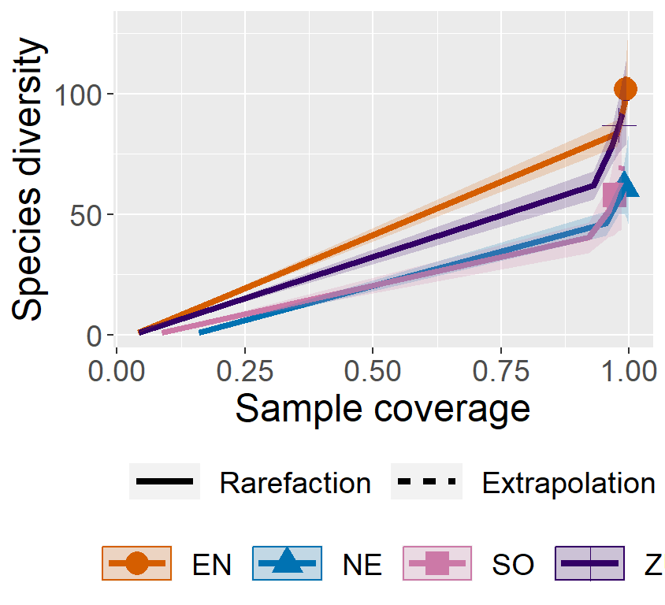

```r
iNEXT(artropodos, conf = 0.98, nboot = 100, knots = 10) %>%
  #> Pasar por el comando de graficacion
  ggiNEXT(type = 3)
```

Recordar que al no haber utilizado el argumento `endpoint`, entonces se tomó como punto máximo el doble del tamaño de referencia.

Otra gran ventaja de graficar con ggplot es que con el argumento `facet.var` **se separan los resultados** para cada sitio, por si permite una visualización más sencilla

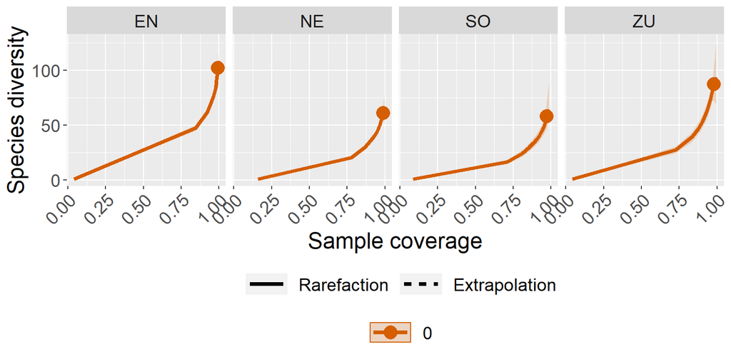

```r
ggiNEXT(res, type = 3, facet.var = "Assemblage") +
  #> se ajustan las etiquetas del eje x para mejor visualización
  theme(axis.text.x = element_text(angle = 45, hjust = 1))
```

Finalmente, una demostración de cómo sacar los valores de un solo sitio, con base en la cantidad de “knots” definidos (aunque no se imprimirá el resultado):

```r
# Sacar el tercer sitio si se usó knots = 40
res$iNextEst$coverage_based[(81:120),]
```

## `rarefaction.sample` {rareNMtests}

Este comando recibe un *objeto tipo matriz* con *muestras en filas*, tanto de **abundancias como incidencias**, pero que **transforman automáticamente como incidencias**. Por lo que a nuestros datos ejemplo, solo necesitaríamos **un paso para sacar cada sitio** (sin considerar el paso que unifica los nombres).

```r
# Juntar todas las filas que pertenecen al mismo sitio (cuatro Parques Distritales)
ensamblaje_unif <- ensamblaje %>%

  #> Crear nueva columna con las dos primeras letras de cada sitio para unificarlos
  mutate(sitio = substr(eventID, start = 1, stop = 2)) %>%

  #> Eliminar la columna con el nombre amplio de sitio
  select(sitio, everything(), -eventID)

# 1. Sacar el sitio a analizar
SO <- ensamblaje_unif %>%  subset(sitio == "SO")
```

Para el uso de rarefacción por cobertura, solo tendrías que manipular **un argumento**: establecer `method = 'coverage'`

```
#> Se introduce en el comando sacando la primera columna
```

```r
resA_RS <- rarefaction.sample(SO[,-1], method = "coverage")
```

```
#> Se imprime la cola de los resultados
```

```r
tail(resA_RS)
```

```
     coverage Hill (q=0)
140 0.8086917   57.05631
141 0.8099972   57.24762
142 0.8112826   57.43762
143 0.8125479   57.62634
144 0.8137931   57.81379
145 0.8150300   58.00000
```

Los resultados son un dataframe con dos columnas, en el que se muestran diferentes valores de cobertura y su riqueza respectiva. Notar que es **solo una rarefacción**, por lo que llega hasta el valor de la riqueza observada.

A continuación se muestra la riqueza del Parque Distrital “SO”

```r
describe_diver(colSums(SO[,-1]))
```

```
    N Riq f1 f2        H       q1        H1
1 603  58 17  6 3.059246 21.31148 0.7534266
```

A continuación se compara el resultado convirtiendo en incidencias antes de usar el comando (es decir, colocando 1 cuando se observó la familia, y 0 cuando no), con el resultado anterior `resA_RS`, en el cual se supone se hizo la conversión de forma automática.

```r
# (b) Convertir a incidencias antes de ingresar al comando
resB_RS <- SO[,-1] %>%
  # Modificar, en todas las columnas, que si el valor es mayor a 0, ponga 1; de lo contrario, 0
  mutate(across(everything(), ~ ifelse(. > 0, 1, 0))) %>%
  rarefaction.sample(method = "coverage")
```

```
#> Crear muestra aleatorio de filas
```

```r
filas <- sample.int(nrow(resA_RS), size = 8)
```

```
#> Imprimir las mismas filas
```

```r
as_tibble(c(A = resA_RS[filas,],
            B = resB_RS[filas,]))
```

```
# A tibble: 8 × 4
  A.coverage `A.Hill (q=0)` B.coverage `B.Hill (q=0)`
       <dbl>          <dbl>      <dbl>          <dbl>
1      0.754           49.9      0.754           49.9
2      0.638           36.7      0.638           36.7
3      0.803           56.3      0.803           56.3
4      0.783           53.6      0.783           53.6
5      0.756           50.1      0.756           50.1
6      0.548           28.6      0.548           28.6
7      0.738           47.8      0.738           47.8
8      0.627           35.6      0.627           35.6
```

Al observar cada fila, se puede observar el mismo resultado.

Este comando **no permite controlar otros aspectos relacionados con la rarefacción-extrapolación por cobertura**, y toca diseñar el propio código para hacer el gráfico. Un aspecto positivo es que indican que **utilizan la fórmula de Chao et al 2014** para la rarefacción con cobertura.

## `rarefaction.individual` {rareNMtests}

En contraposición de `rarefaction.samples` este trabaja con **abundancias**, pero solo lo recibe en formato de vector. Por lo que además de sacar cada sitio de los datos ejemplo, se debe agrupar en un solo vector, para **dos pasos** en total.

```r
# Juntar todas las filas que pertenecen al mismo sitio (cuatro Parques Distritales)
ensamblaje_unif <- ensamblaje %>%

  #> Crear nueva columna con las dos primeras letras de cada sitio para unificarlos
  mutate(sitio = substr(eventID, start = 1, stop = 2)) %>%

  #> Eliminar la columna con el nombre amplio de sitio
  select(sitio, everything(), -eventID)

# 1. Sacar el sitio a analizar
SO <- ensamblaje_unif %>%  subset(sitio == "SO")

# 2. Convertirlo en un vector (sin la primera columna)
SO_vector <- SO[,-1] %>% colSums()
```

Y en este comando, al igual que el anterior, solo requiere la manipulación de **un argumento**:

```r
res_RI <- rarefaction.individual(SO_vector, method = "coverage")
tail(res_RI)
```

```
     coverage Hill (q=0)
598 0.9716744   57.85871
599 0.9717080   57.88703
600 0.9717413   57.91532
601 0.9717746   57.94358
602 0.9718076   57.97181
603 0.9718406   58.00000
```

De igual forma, entrega una columna con los valores de cobertura y otra con la riqueza, pero sigue siendo **solo rarefacción** porque llega hasta la riqueza observada:

```r
# Riqueza en el Parque Distrital SO
describe_diver(SO_vector)
```

```
    N Riq f1 f2        H       q1        H1
1 603  58 17  6 3.059246 21.31148 0.7534266
```

A diferencia del anterior, este comando **permite controlar tres argumentos** opcionales útiles para la rarefacción por cobertura:

- `powerfun`, el cual permite controlar con qué proporción de submuestras se hará la rarefacción (es decir si de individuo en individuo, o una proporción menor). Por defecto tiene valor de 1, lo que representa que se hará la rarefacción completa (en el ejemplo que venimos manejando, serían 603, que corresponde a los individuos registrados). Ellos mencionan que, **cuando se tiene entre 1000 y 10000 individuos**, entonces el comando puede ser demandante computacionalmente, y ahí recomiendan usar valores entre 0.6 y 0.8 (los cuales representan una disminución en la cantidad total de submuestreos).
- `log.scale`, permite controlar el tipo de escala que tendrán cada una de las submuestras entre sí. Los valores posibles son `FALSE` (valor por defecto) o `TRUE`, que representan, respecitvamente, que la submuenstras están espaciadas a intervalos regulares, o que están espaciadas en una escala logarítmica.
- `inds`, que permite especificar un valor o vector sobre con cuántos individuos se quiere hacer la rarefacción.

NOTA: Aunque todos los anteriores se refieran o se especifíquen en la cantidad de individuos, el resultado es en valores de cobertura.

Por ejemplo si decido mirar el valor de cobertura para 600 individuos (que es una rarefacción, ya que los observados fueron 603):

```r
rarefaction.individual(SO_vector, method = "coverage", inds = 600)
```

```
   coverage Hill (q=0)
1 0.9717413   57.91532
```

O, con los otros dos argumentos

```
#> Hacer rarefacción de abundancias con menos cantidad de individuos y en escala log
```

```r
rarefaction.individual(SO_vector, method = "coverage", powerfun = 0.6, log.scale = TRUE) %>% head()
```

```
    coverage Hill (q=0)
1 0.08688562   1.000000
2 0.16040456   1.913114
3 0.22288326   2.752710
4 0.27623256   3.529827
5 0.32202207   4.253594
6 0.36154133   4.931572
```

Pero le veo inconveniente el usar `powerfun` y `log.sacle` con cobertura. Porque en el primero, no es intutitivo el resultado obtenido, y sobre el segundo, no tengo conocimiento de literatura que recomiende utilizar la escala logarítmica.

Por otro lado, `inds` sí permitiría evaluar un punto en particular de cobertura (si defino el mínimo entre los sitios y lo utilizo como ese valor) pero funciona en términos de individuos, no de cobertura.

Entonces a estos últimos argumentos no les veo muchas ventajas, además que solamente sirve para rarefacción.

## `Coverage` y `Coverage2Size` {entropart}

El comando recibe *un vector* únicamente de **abundancias**. Así que desde nuestros datos ejemplo, hay dos opciones: o sumar todos los sitios y tomar la cobertura como si todo perteneciera al mismo ensamblaje (lo que toma **dos pasos**, y para este caso particular, no es necesario modificar los nombres de los sitios), o sacar cada sitio para calcularle su cobertura (que implica **tres pasos por cada uno**). Para hacer una comparación, se sumarán todos los sitios, y luego, se mostrará como sería el procedimiento para hacerlo por sitio.

```r
# 1. Sumar todos los sitios
ensamblaje_abund <- ensamblaje %>%

  #> Quitar la columna con el identificador de sitio
  select(everything(), -eventID) %>%

  #> Sumar todos los datos por columna
  summarise(across(everything(), sum))

# 2. Convertir en un vector
vector_abund <- unlist(as.vector(ensamblaje_abund))
```

Con esto, ya se puede utilizar el comando, el cual necesita la manipulación de **un solo** argumento, `Level` en el cual se coloca cualquier valor de abundacia (sea menor o mayor a la observada), del cual se quiere conocer la cobertura (**tanto para rarefacción como para extrapolación**):

```r
Coverage(vector_abund, Level = 5200) # no sé cuanto es ese 150
```

```
     Chao
0.9973404
```

El resultado es el valor de cobertura para la abundancia definida. Sin embargo, me parece negativo que **solo se puede de a un solo valor, y que además no indica si es rarefacción o extrapolación**. Por ejemplo, en este caso me tocó usar otro comando para determinar que sería extrapolación, pues recordemos la abundancia total observada en el estudio fue menor a 5000:

```r
describe_ensa
```

```
     N Riq f1 f2        H      q1        H1
1 4944 136 15 19 3.888783 48.8514 0.7915848
```

Algo interesante es que tiene el argumento `Estimator`, el cual **permite específicar qué formula de cobertura se va a utilizar** (y de las cuales se tiene referencias en la ayuda del comando). Tiene **cuatro opciones**:

- `ZhangHuang`, donde se menciona el artículo de Zhang y Huang, 2007
- `Chao`, donde se menciona el artículo de Chao y Shen 2010
- `Turing`, donde se menciona el artículo de Good de 1953
- `Good`, donde se relaciona fórmula, pero se asume está en Chao, Lee y Chen 1988

```r
# Imprimir los valores
sapply(X = c("ZhangHuang", "Chao", "Turing", "Good"),
       FUN = function(x) Coverage(vector_abund, Level = 4200, Estimator = x))
```

```
Warning in Coverage(vector_abund, Level = 4200, Estimator = x): Correction has
not been recognized

Warning in Coverage(vector_abund, Level = 4200, Estimator = x): Correction has
not been recognized
```

```
ZhangHuang  Chao.Chao     Turing  Good.Good
        NA  0.9956867         NA  0.9956867
```

NOTA: Se supone que por defecto está la `ZhangHuang`, pero en estos resultados salió por defecto `Chao`, al parecer está ligado a ese warning, pues no hubo resultado para ese método. Si se intenta utilizar una abundancia mayor a la observada con el estimador **`Good`, sale un warning de que con éste solo es posible la interpolación**, **pero del resto no se menciona nada, ni siquiera en la ayuda del comando**.

### Para un sitio

Ahora, en caso de que se quiera usar el comando para un solo sitio, se podría hacer el siguiente procedimiento:

```r
# Juntar todas las filas que pertenecen al mismo sitio (cuatro Parques Distritales)
ensamblaje_unif <- ensamblaje %>%

  #> Crear nueva columna con las dos primeras letras de cada sitio para unificarlos
  mutate(sitio = substr(eventID, start = 1, stop = 2)) %>%

  #> Eliminar la columna con el nombre amplio de sitio
  select(sitio, everything(), -eventID)

# 1. Sumar las abundancias de un mismo sitio
ensamblaje_unif <- ensamblaje_unif %>%
  group_by(sitio) %>%
  summarise(across(everything(), sum))

# 2. Sacar el sitio deseado
abund_sitio <- ensamblaje_unif %>% filter(sitio == "SO")

# 3. Convertir en vector (quitando la primera columna)
vector_sitio <- abund_sitio[,-1] %>% as.vector() %>% unlist()

# Ya se puede usar en el comando
Coverage(vector_sitio)
```

```
ZhangHuang
 0.9718405
```

En caso de querer visualizar los valores para cada sitio, se tendría que hacer una función que tome desde el punto dos del chunk anterior

```r
filtrar_sitio <- function(x){
  ensamblaje_unif %>%
    filter(sitio == x) %>%
    select(-sitio) %>%
    as.vector() %>%
    unlist()
}

sapply(X = c("EN", "NE", "ZU", "SO"),
       FUN = function(x) Coverage(filtrar_sitio(x), Level = 603, Estimator = "Chao"))
```

```
  EN.Chao   NE.Chao   ZU.Chao   SO.Chao
0.9677387 0.9773574 0.9613777 0.9718406
```

```
#> o con extrapolación al doble de tamaño del sitio con menos abundancia
```

```r
sapply(X = c("EN", "NE", "ZU", "SO"),
       FUN = function(x) Coverage(filtrar_sitio(x), Level = 1206, Estimator = "Chao"))
```

```
  EN.Chao   NE.Chao   ZU.Chao   SO.Chao
0.9857635 0.9942757 0.9854114 0.9861090
```

Y ya se reemplazaría cada `Estimator`.

Honestamente no sé que pensar al respecto. Solo admite un vector de abundancias, no indica en su resultado si es rarefacción o extrapolación, y si se quiere hacer para cada sitio el procedimiento es algo largo Lo único que le veo de ventaja es que incluye las fórmulas.

Ahora, el comando `Coverage2Size` es como una herramienta adicional, la cual permite colocar un determinado valor de cobertura muestral, y devuelve el tamaño de muestra, permitiendo también tanto **interpolación como extrapolación**. Por ejemplo, sabiendo que la abundancia total encontrada en el sitio “SO” fue de 603, y obtuvo una cobertura de 97% con la fórmula de Zhang y Huang (ver código del resultado), entonces se puede preguntar cuánto se requiere para subir la cobertura al 98.5%, o al 90%.

```r
# Se aplica el comando al vector con las abundancias del sitio SO
Coverage2Size(vector_sitio, SampleCoverage = 0.985)
```

```
[1] 1140
```

```r
# Se aplica con una cobertura de 90%
Coverage2Size(vector_sitio, SampleCoverage = 0.9)
```

```
[1] 155
```

Y, como se observa, el resultado es el valor puntual del tamaño de la muestra calculado para esa cobertura en particular. Sin embargo, dado que el comando anterior es explícito en que utiliza varias fórmulas (y que es evidente que no en todos los casos aplican todas), **veo como negativo que no se menciona cuál de todas las fórmulas es la que se utiliza para hacer el cálculo**

Entonces: Si el objetivo es obtener valores de rarefacción, puede ser puntual (excepto en los estudios en que la tabla esté organizada para varios sitios, como este caso). Y si bien tiene el aspecto extra de considerar varias funciones, le veo el inconveniente al intentar hacer extrapolación, no se explica el porqué algunas sirven y otras no.

# Comparación de los comandos analizados

De los 6 comandos revisados (estimateD, iNEXT, rarefaction.sample, rarefaction.individual, Coverage, Coverage2Size), repartidos entre 3 paquetes (iNEXT, rareNMtests, entropart; cada uno con dos), resalto los siguientes rasgos a comparar:

- Acepta datos abundancia/incidencia
- Pasos desde los datos referencia hasta el input
- Cantidad de argumentos
- Si hace rarefacción, extrapolación o ambas
- Aspectos extra controlables
- Se cita la referencia de la fórmula

|  | iNEXT estimateD | iNEXT | rareNMtests rarefaction.sample | rareNMtests rarefaction.individual | entropart Coverage | entropart Coverage2Size |
| --- | --- | --- | --- | --- | --- | --- |
| Acepta datos de abundancia | SI | SI | SI | SI | SI | SI |
| Acepta datos de incidencia | SI | SI | SI | NO | NO | NO |
| Pasos desde los datos referencia hasta el input | 2 | 2 | 1 | 2 | >2 | >2 |
| Cantidad de argumentos | 3 | 1 | 1 | 1 | 1 | 1 |
| Aspectos extra | Intervalo de confianza Cantidad de bootstrap Nivel/es particular/es de cobertura Sigue recomendaciones de litertura | Integración grafica sencilla Definir punto final de cobertura Definir cantidad de puntos en gráfica Controlar intervalo de confianza Definir número de réplicas | N/A | Argumento para disminuir demanda computacional Definir punto final de cobertura | Tiene cuatro fórmulas de cobertura | N/A |
| Tiene referencia a la(s) formula(s) | NO | NO | SI | SI | SI | NO |

Con esto en mente, considero muy buenas opciones los comandos del paquete `iNEXT`, puesto que `estimateD` tuvo el resultado más práctico tanto para rarefacción y extrapolación (sea por abundancia o incidencia), y `iNEXT` permite generar gráficos de forma sencilla, lo cual se evidencia en la cantidad de ventajas extra que tienen con respecto al resto de comandos. Si bien tiene el punto negativo de que no se cita las fórmulas utilizadas, considerando que los autores son los mismos referentes de la literatura en el tema, no lo veo como inconveniente.

# Referencias

Fauth, JE, J Bernardo, Mark Camara, WJ Resetarits Jr, Josh Van Buskirk, and SA McCollum. 1996. “Simplifying the Jargon of Community Ecology: A Conceptual Approach.” *The American Naturalist* 147 (2): 282–86.